# Homework 3 — More APIs, Classification, NLP

## 10. (5 points)

Use the vader lexicon to conduct sentiment analysis on the word tokens to determine if consumer complaints express positive, neutral, or negative sentiments. Create a histogram of the sentiment scores, and make a barplot to show the counts of tokens by sentiment category. Make another barplot to compare sentiment category counts by product categories. Make another barplot to show which words have top positive sentiment scores and which words have most negative sentiment scores. Summarize and interpret your results.

```python
# Initialize VADER
sia = SentimentIntensityAnalyzer()

# Build token-frequency table from cleaned tokens (from Q8)
token_freq_df = pd.DataFrame(
    Counter(cleaned_tokens).items(),
    columns=["word", "count"]
)

# VADER compound score per unique token
token_freq_df["sentiment_score"] = token_freq_df["word"].apply(
    lambda w: sia.polarity_scores(w)["compound"]
)

# Convert score to sentiment category
def get_sentiment_category(score):
    if score >= 0.05:
        return "Positive"
    if score <= -0.05:
        return "Negative"
    return "Neutral"

token_freq_df["sentiment_category"] = token_freq_df["sentiment_score"].apply(get_sentiment_category)

display(token_freq_df.head())
print(f"Unique cleaned tokens scored: {token_freq_df.shape[0]}")
```

|  | word | count | sentiment_score | sentiment_category |
| --- | --- | --- | --- | --- |
| 0 | spouse | 328 | 0.0 | Neutral |
| 1 | attended | 180 | 0.0 | Neutral |
| 2 | school | 1041 | 0.0 | Neutral |
| 3 | closed | 20302 | 0.0 | Neutral |
| 4 | due | 30754 | 0.0 | Neutral |

```
Unique cleaned tokens scored: 42190
```

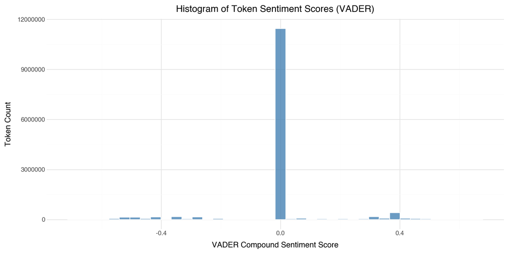

```python
# Histogram of sentiment scores (weighted by token counts)
(
    ggplot(token_freq_df, aes(x="sentiment_score", weight="count"))
    + geom_histogram(bins=40, fill="steelblue", color="white", alpha=0.8)
    + labs(
        title="Histogram of Token Sentiment Scores (VADER)",
        x="VADER Compound Sentiment Score",
        y="Token Count"
    )
    + theme_minimal()
    + theme(figure_size=(10, 5))
)
```

```python
# Count tokens by sentiment category
sentiment_category_counts = (
    token_freq_df.groupby("sentiment_category", as_index=False)["count"]
    .sum()
)

display(sentiment_category_counts)
```

|  | sentiment_category | count |
| --- | --- | --- |
| 0 | Negative | 1082565 |
| 1 | Neutral | 11511261 |
| 2 | Positive | 1103837 |

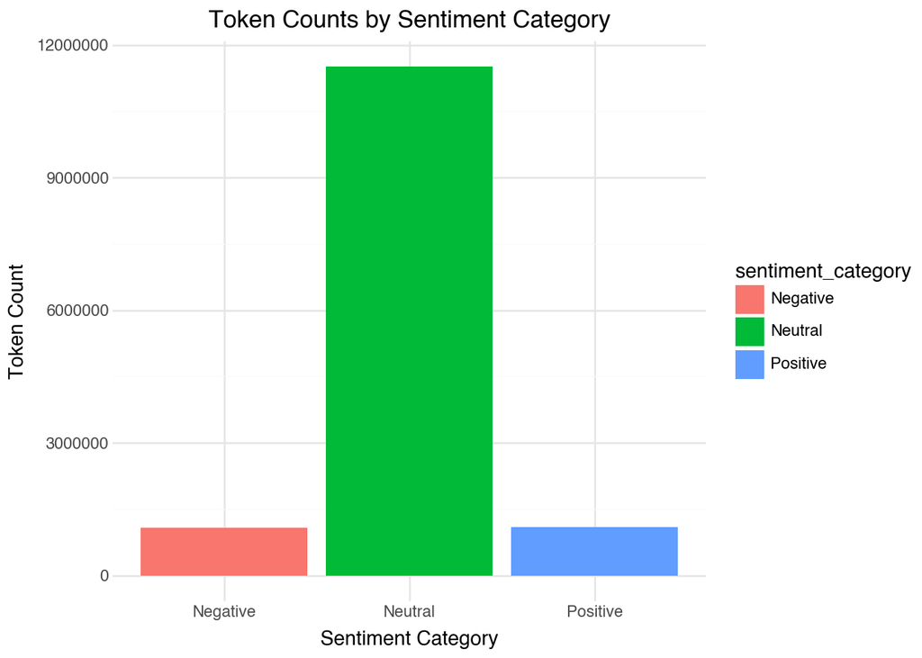

```python
(
    ggplot(sentiment_category_counts, aes(x="sentiment_category", y="count", fill="sentiment_category"))
    + geom_col()
    + labs(
        title="Token Counts by Sentiment Category",
        x="Sentiment Category",
        y="Token Count"
    )
    + theme_minimal()
    + theme(figure_size=(7, 5))
)
```